# Making inline statistics commands for LaTeX using R

- Show All Code
- Hide All Code
- View Source

This post shows how to make latex commands to insert model statistics.

R

LaTeX

Published

April 28, 2024

In this post I describe a workflow approach for reproducible reporting of inline statistics for researchers who do their analysis in R but the final writeup in LaTeX/Overleaf without writing in RMarkdown as an intermediate step. If you are a diehard RMarkdown/Quarto-only fan, then this is not for you. If you just want to see how the final function works on Overleaf, skip to the last section.

If you want to use the final code that we build up here, you can download the source file from my github [here](https://github.com/tsostarics/sosdiss2/blob/main/R/make_latex_switch.R). Note that this version is slightly different than what’s used here, but is generally equivalent in functionality. Also, this file is part of a larger package of convenience functions for my dissertation, so I’d recommend just downloading the one R file instead of installing the package.

## Motivation

I’ve used R, RMarkdown, and Quarto documents throughout grad school and generally like using them for organizing my analyses and notes. But, I’ve been writing papers (and homework writeups, handouts, etc.) using LaTeX for well over 12 years now— since before ShareLatex merged with Overleaf. I can appreciate RMarkdown and Quarto’s capabilities for writing articles but honestly the few times I’ve tried to stick solely with Quarto I couldn’t quite reach the level of flexibility in PDF output that I get out the box with LaTeX.

One approach I’ve taken in previous work was to write *just* my results/analysis sections using RMarkdown, then render that to a LaTeX fragment (no preamble, begin document, etc.) that I can `\input` into my main LaTeX document. This was nice because I could do tricks like using tibbles or lists to keep track of statistical results (see [TJ Mahr’s post here with an example](https://tjmahr.com/lists-knitr-secret-weapon/)) and write functions to format and insert inline statistics like `$(\hat\beta=0.6, 95\% CI: [0.21,0.98])$` for me without ever needing to worry about handling the numbers by hand. Add a bash script to push the rendered .tex files to a repository, sync that with overleaf, and everything would be as it should be. But, this means that if I wanted to edit the results section after reading it in Overleaf, I would have to remember to sync my overleaf changes, change the RMarkdown file, rerender, then push the new .tex file again. It became a bit cumbersome whenever I only needed to do small prose changes that had nothing to do with the numbers.

So here’s a different approach focused on better handling the division of labor between prose and inline statistics, but can generalize to things like tables. The goal is to replicate inline R functionality in RMarkdown, where for example we might have our statistics in a list called `model_stats`, which we can index like `r model_stats$my_effect`, assuming this would result in a number or a formatted inline statistics string. So, we’re going to use R to create a LaTeX command like `\modelStats{my_effect}`, which we can then source into our LaTeX project The benefit here is that the only thing R exports is the numbers for the analysis, not the prose, so we only need to worry about occasionally updating our commands on the R side.

I’m going to show a simple example that I’ve done recently that’s been working quite well for writing my thesis. It isn’t intended to necessarily work out of the box for every type of model, but I’ll point out a couple of workarounds I used and some potential extensions. This command is basically just a switch statement.[^1] I’m basing the LaTeX implementation on the discussion from [this stackexchange post](https://tex.stackexchange.com/questions/508268/expandable-case-insensitive-switch-case-for-string-comparison), so give it a look if you’re curious.

## The LaTeX part: Writing the command

The command we’re going to write looks something like the below. I’m not an expert on `expl3` syntax, but here’s the gist of what’s going on:

- Define a boolean value so we know when we’ve matched a coefficient
- Define a new command `statvalue` that takes a single argument. We need to use `m` otherwise the command won’t work when used inside of other commands like `footnote{}`
- Take whatever we give to `statvalue`, `#1`, and standardize the capitalization using foldcase (basically, make it all lowercase but technically it’s not merely lowercasing)
- Look through our switch cases, formatted as `{ matchtext } { result }`. If `#1` matches with `matchtext`, then we flag that we found a match by setting our boolean `found` to true, then return the rest of the result (formatted text).
- If we don’t find a match, then `found` is still false, so we’ll return ERROR in big red letters so we can see it in the rendered text.

```latex
\ExplSyntaxOn
\newboolean{found}
\setboolean{found}{false}
\NewDocumentCommand \statvalue{ m }
{
\str_case_e:nn { \str_foldcase:e { #1 } }
{
{ groupTreatment } { \setboolean{found}{true} $(\hat\beta = 0.79, CI=[0.58,0.99]), p<.001$ }
{ age } { \setboolean{found}{true} $(\hat\beta = 0.09, CI=[-0.21,0.15]), p<.001$ }
}
\ifthenelse{\boolean{found}}{}{{\color{red} \large ERROR}}
\setboolean{found}{false}
}
\cs_generate_variant:Nn \str_foldcase:n { e }
\ExplSyntaxOff
```

So then we can write text like:

[output not shown]

Which then is replaced under the hood with:

[output not shown]

So, our work on the R front has two parts. First, we need the boilerplate for the command. Second, we need to format our model results as a string and then inject it into the boilerplate.

## The R part 1: Getting the modeling results ready

First I’ll fit a very simple mixed model, I’ll ignore the singularity warning since this is just an example so we have something to work with.

```r
library(palmerpenguins) # For dataset
library(lme4)           # For mixed models
library(lmerTest)       # For p value output

penguin_model <-
  lmer(bill_length_mm ~ bill_depth_mm * species  + (1|island),
       data = palmerpenguins::penguins)

summary(penguin_model)
```

```
Linear mixed model fit by REML. t-tests use Satterthwaite's method [
lmerModLmerTest]
Formula: bill_length_mm ~ bill_depth_mm * species + (1 | island)
   Data: palmerpenguins::penguins

REML criterion at convergence: 1582.9

Scaled residuals:
    Min      1Q  Median      3Q     Max
-3.1860 -0.6306  0.0235  0.6493  4.2374

Random effects:
 Groups   Name        Variance Std.Dev.
 island   (Intercept) 0.000    0.000
 Residual             5.976    2.445
Number of obs: 342, groups:  island, 3

Fixed effects:
                               Estimate Std. Error       df t value Pr(>|t|)
(Intercept)                     23.0681     3.0165 336.0000   7.647 2.18e-13
bill_depth_mm                    0.8570     0.1641 336.0000   5.224 3.08e-07
speciesChinstrap                -9.6402     5.7154 336.0000  -1.687 0.092590
speciesGentoo                   -5.8386     4.5353 336.0000  -1.287 0.198850
bill_depth_mm:speciesChinstrap   1.0651     0.3100 336.0000   3.435 0.000666
bill_depth_mm:speciesGentoo      1.1637     0.2789 336.0000   4.172 3.84e-05

(Intercept)                    ***
bill_depth_mm                  ***
speciesChinstrap               .
speciesGentoo
bill_depth_mm:speciesChinstrap ***
bill_depth_mm:speciesGentoo    ***
---
Signif. codes:  0 '***' 0.001 '**' 0.01 '*' 0.05 '.' 0.1 ' ' 1

Correlation of Fixed Effects:
            (Intr) bll_d_ spcsCh spcsGn bl__:C
bll_dpth_mm -0.998
spcsChnstrp -0.528  0.527
speciesGent -0.665  0.664  0.351
bll_dpth_:C  0.528 -0.529 -0.998 -0.351
bll_dpth_:G  0.587 -0.588 -0.310 -0.993  0.311
optimizer (nloptwrap) convergence code: 0 (OK)
boundary (singular) fit: see help('isSingular')
```

Hurray, lots of p<.05, time to publish[^2] In our results section we’ll report on the effect estimate $\hat\beta$, the 95% confidence interval, and the $p$ value, but we need to format all this information in a consistent way. We can always add more information as needed (e.g., if a reviewer says they want the $t$ value reported inline as well). We’ll use `broom.mixed::tidy` to get just our fixed effect estimates, and then I’ll do some quick rounding and post processing of the p values.

```r
library(broom.mixed)
library(dplyr)

model_results <-
  penguin_model |>
  tidy(effects='fixed', conf.int = TRUE) |>
  dplyr::mutate(p.value = scales::pvalue(p.value,accuracy = .01,add_p = TRUE),
                across(where(is.numeric), ~round(.,2)),)

model_results
```

```
# A tibble: 6 × 9
  effect term      estimate std.error statistic    df p.value conf.low conf.high
  <chr>  <chr>        <dbl>     <dbl>     <dbl> <dbl> <chr>      <dbl>     <dbl>
1 fixed  (Interce…    23.1       3.02      7.65   336 p<0.01     17.1      29
2 fixed  bill_dep…     0.86      0.16      5.22   336 p<0.01      0.53      1.18
3 fixed  speciesC…    -9.64      5.72     -1.69   336 p=0.09    -20.9       1.6
4 fixed  speciesG…    -5.84      4.54     -1.29   336 p=0.20    -14.8       3.08
5 fixed  bill_dep…     1.07      0.31      3.44   336 p<0.01      0.46      1.67
6 fixed  bill_dep…     1.16      0.28      4.17   336 p<0.01      0.62      1.71
```

Now, we need to modify the terms a bit to make them more amenable to the pattern matching for the LaTeX command. Specifically, we’ll need to lowercase everything and change the `:` character to something else. Since `i` is used for interactions, I’ll change it to `i`. Looking ahead, we’ll also drop the parentheses for the intercept since it looks weird to write `\stavalue{(intercept)}`.

```r
model_results <- mutate(model_results,
                        term = tolower(term),
                        term = gsub(":", "i", term),
                        term = gsub("[)(]", "", term))

model_results$term
```

```
[1] "intercept"                      "bill_depth_mm"
[3] "specieschinstrap"               "speciesgentoo"
[5] "bill_depth_mmispecieschinstrap" "bill_depth_mmispeciesgentoo"
```

We can wrap all these steps into a function to use with other models later on:

```r
process_coefs <- function(mdl) {
  mdl |>
    broom.mixed::tidy(effects='fixed', conf.int = TRUE) |>
    dplyr::mutate(p.value = scales::pvalue(p.value,accuracy = .01,add_p = TRUE),
                  across(where(is.numeric), ~round(.,2)),
                  term = tolower(term),
                  term = gsub(":", "i", term),
                  term = gsub("[)(]", "", term))
}
```

## The R part 2: Writing the boilerplate command

What we want is a function that takes our model results dataframe and spits out a formatted LaTeX command. If we think we might have more than 1 model to report, we’re going to need parameters to name the command and a boolean to omit the `found` boolean.[^3] We’ll also add a parameter for the formatted inline stats strings, in case we need to modify what/how we report at a later point. This will get injected into the case boilerplate. Here is the pseudocode for the function in case you want to think or work through the steps yourself.

```r
make_latex_switch <-
  function(model_coef_df,
           fstring = r"($(\hat\beta = {estimate}, CI=[{conf.low},{conf.high}])$)",
           command_name = "statvalue",
           add_found_boolean = TRUE) {

    # Set up the start of the command with the expl3 lines

    # Check whether we need to add the found boolean

    # Set up the first couple of lines


    # Take the formatted string from the user and embed it within the syntax
    # needed for the conditional statements

    # Take the full formatted string and inject the model values

    # Add together all the lines, along with the ending parts to close off the
    # command definition

    # Print the new expression with the newlines in a copy-pasteable format

    # Return the lines as a character vector in case the user wants to hold on
    # to them (which is reasonable)
  }
```

And here is the function filled out.[^4] Note that there are of course other ways to implement this. For example, we might create a named list of formatted strings outside of this function then iterate over the names and values of that list to inject them into the boilerplate.

```r
make_latex_switch <-
  function(model_coef_df,
           command_name = "statvalue",
           fstring = r"($(\hat\beta = {estimate}, CI=[{conf.low},{conf.high}], {p.value})$)",
           add_found_boolean = TRUE) {

    # Set up the start of the command with the expl3 lines
    starting_lines <- c(r"(\ExplSyntaxOn)")

    # Base case is handled by a boolean called "found", if we have already defined
    # this elsewhere then we can omit it as needed
    if (add_found_boolean)
      starting_lines <- c(starting_lines, r"(\newboolean{found})")

    starting_lines <-
      c(
        starting_lines,
        r"(\setboolean{found}{false})",
        paste0(r"(\NewDocumentCommand \)", command_name, r"({ m })"),
        r"(  {)",
        r"(    \str_case_e:nn { \str_foldcase:e { #1 } })",
        r"(      {)")


    # Take the formatted string from the user and embed it within the syntax
    # needed for the conditional statements
    fstring <-
      paste0(
        "        {{ {term} }} {{ \\setboolean{{found}}{{true}} ", fstring, " }}"
      )

    # Take the full formatted string and inject the model values
    mdl_lines <- glue::glue(fstring, .envir = model_coef_df)

    # Add together all the lines, along with the ending parts to close off the
    # command definition
    all_lines <-
      c(starting_lines,
        mdl_lines,
        r"(      })",
        r"(    \ifthenelse{\boolean{found}}{}{{\color{red} \large ERROR}})",
        r"(    \setboolean{found}{false})",
        r"(  })",
        r"(\cs_generate_variant:Nn \str_foldcase:n { e })",
        r"(\ExplSyntaxOff)") |>
      paste0("\n") # add newlines for formatting

    # Print the new expression with the newlines in a copy-pasteable format
    cat(all_lines)

    # Return the lines as a character vector in case the user wants to hold on
    # to them (which is reasonable)
    invisible(all_lines)
  }
```

## The integration part

So now we have our function and model results, let’s make some commands.

```r
penguin_model |>
process_coefs() |>
  make_latex_switch("statValue")
```

```
\ExplSyntaxOn
 \newboolean{found}
 \setboolean{found}{false}
 \NewDocumentCommand \statValue{ m }
   {
     \str_case_e:nn { \str_foldcase:e { #1 } }
       {
         { intercept } { \setboolean{found}{true} $(\hat\beta = 23.07, CI=[17.13,29], p<0.01)$ }
         { bill_depth_mm } { \setboolean{found}{true} $(\hat\beta = 0.86, CI=[0.53,1.18], p<0.01)$ }
         { specieschinstrap } { \setboolean{found}{true} $(\hat\beta = -9.64, CI=[-20.88,1.6], p=0.09)$ }
         { speciesgentoo } { \setboolean{found}{true} $(\hat\beta = -5.84, CI=[-14.76,3.08], p=0.20)$ }
         { bill_depth_mmispecieschinstrap } { \setboolean{found}{true} $(\hat\beta = 1.07, CI=[0.46,1.67], p<0.01)$ }
         { bill_depth_mmispeciesgentoo } { \setboolean{found}{true} $(\hat\beta = 1.16, CI=[0.62,1.71], p<0.01)$ }
       }
     \ifthenelse{\boolean{found}}{}{{\color{red} \large ERROR}}
     \setboolean{found}{false}
   }
 \cs_generate_variant:Nn \str_foldcase:n { e }
 \ExplSyntaxOff
```

We can take the output of this and just copy paste it into our preamble on overleaf like in the below picture. Note that we need to include the `xparse` and `ifthen` packages (if one of your packages doesn’t already include them). We can ignore the error that overleaf flags on line 23, it’s just because of the expl3 syntax.

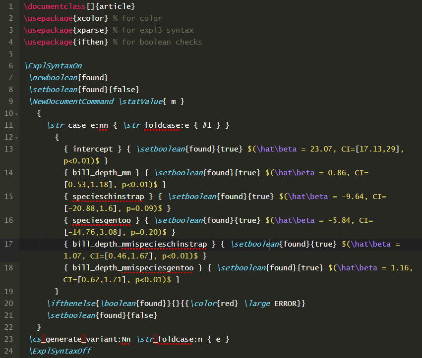

Then we can type our LaTeX writeup and render it like so:

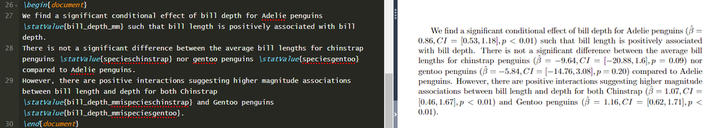

If we have multiple models, then we might want to write a new tex file that we can source into the project instead:

```r
mdl2 <- lmer(flipper_length_mm ~ body_mass_g + (1|species),
             data = palmerpenguins::penguins)
mdl3 <- lmer(bill_depth_mm ~ body_mass_g*bill_length_mm + (1|sex) + (1|species),
             data = palmerpenguins::penguins)
switch1 <- make_latex_switch(process_coefs(penguin_model), "statValue")
switch2 <- make_latex_switch(process_coefs(mdl2), "flipperModelValue",add_found_boolean = FALSE)
switch3 <- make_latex_switch(process_coefs(mdl3), "depthModelValue",add_found_boolean = FALSE)

c(switch1, switch2, switch3) |>
  writeLines("inlinestats.tex", sep = "")
```

Then we can add that tex file to our overleaf project and clean up our preamble accordingly:

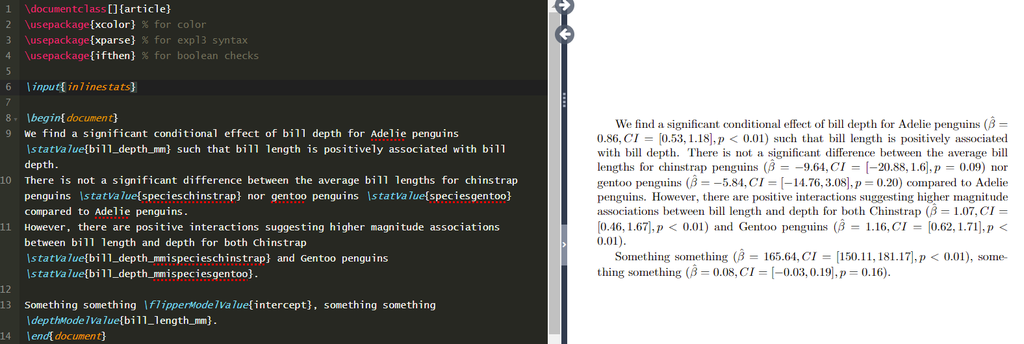

Full document code below:

```latex
\documentclass[]{article}
\usepackage{xcolor} % for color
\usepackage{xparse} % for expl3 syntax
\usepackage{ifthen} % for boolean checks

\input{inlinestats}

\begin{document}
We find a significant conditional effect of bill depth for Adelie penguins \statValue{bill_depth_mm} such that bill length is positively associated with bill depth.
There is not a significant difference between the average bill lengths for chinstrap penguins \statValue{specieschinstrap} nor gentoo penguins \statValue{speciesgentoo} compared to Adelie penguins.
However, there are positive interactions suggesting higher magnitude associations between bill length and depth for both Chinstrap \statValue{bill_depth_mmispecieschinstrap} and Gentoo penguins \statValue{bill_depth_mmispeciesgentoo}.

Something something \flipperModelValue{intercept}, something something \depthModelValue{bill_length_mm}.
\end{document}
```

### Some extensions

Obviously this was just a simple implementation, but you can extend either the R-side processing/formatting or LaTeX-side command as needed. For example, if you have a cumulative link model fit with brms, the threshold coefficients will look like `intercept[1]`, so you might want to adjust these to something like `theta1` or `intercept1`. Also, you might want to add some error handling to the `make_latex_switch` function to make sure the command name you use is wellformed.

On the LaTeX side, I’m really not very familiar with using expl3 so I don’t have an idea about how it might interact with other packages, affect compile times, etc.

## Footnotes

[^1]: For those unfamiliar, a switch statement (oversimplified) is like a series of multiple conditionals, so instead of writing out if x=A, B else if x=C, D else if […] else Z, you can write something like switch(x) A->B, C->D, […], Z.
[^2]: This is a joke if it isn’t obvious.
[^3]: The boolean value only needs to be defined once in the document, so we want to include it for our first command but not redefine it multiple times, as this will throw an error in LaTeX.
[^4]: Yes yes I know we’re growing a vector, let’s set that issue aside for the time being. One could imagine a different implementation where the entire boilerplate is created beforehand and only joined with the model lines at the end. Performance is not a huge issue for this kind of thing unless you’re trying to make thousands of commands in bulk, in which case you probably have other more serious problems to deal with.